# Project1

sudhan_maharjan

September 23, 2018

## Project 1

In this project, you’re given a text file with chess tournament results where the information has some structure. Your job is to create an R Markdown file that generates a .CSV file (that could for example be imported into a SQL database) with the following information for all of the players:

Player’s Name, Player’s State, Total Number of Points, Player’s Pre-Rating, and Average Pre Chess Rating of Opponents

For the first player, the information would be: Gary Hua, ON, 6.0, 1794, 1605

1605 was calculated by using the pre-tournament opponents’ ratings of 1436, 1563, 1600, 1610, 1649, 1663, 1716, and dividing by the total number of games played.

If you have questions about the meaning of the data or the results, please post them on the discussion forum. Data science, like chess, is a game of back and forth.

The chess rating system (invented by a Minnesota statistician named Arpad Elo) has been used in many other contexts, including assessing relative strength of employment candidates by human resource departments. You may substitute another text file (or set of text files, or data scraped from web pages) of similar or greater complexity, and create your own assignment and solution. You may work in a small team. All of your code should be in an R markdown file (and published to rpubs.com); with your data accessible for the person running the script.

# Exerct from the text file

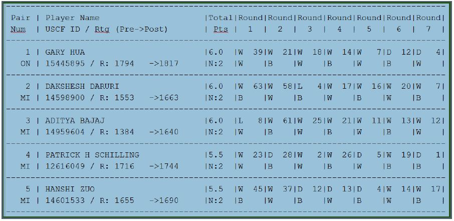

R interface

Looking at the data, the data is not good to be transferred to SQL. We have to do some kind of editing and formatting.

Let’s read the file in R

```r
lines <- read.table("https://raw.githubusercontent.com/maharjansudhan/DATA607/master/tournamentinfo.txt", header=FALSE, sep="\n")
lines
```

```
##                                                                                             V1
## 1    -----------------------------------------------------------------------------------------
## 2    Pair | Player Name                     |Total|Round|Round|Round|Round|Round|Round|Round|
## 3    Num  | USCF ID / Rtg (Pre->Post)       | Pts |  1  |  2  |  3  |  4  |  5  |  6  |  7  |
## 4    -----------------------------------------------------------------------------------------
## 5        1 | GARY HUA                        |6.0  |W  39|W  21|W  18|W  14|W   7|D  12|D   4|
## 6       ON | 15445895 / R: 1794   ->1817     |N:2  |W    |B    |W    |B    |W    |B    |W    |
## 7    -----------------------------------------------------------------------------------------
## 8        2 | DAKSHESH DARURI                 |6.0  |W  63|W  58|L   4|W  17|W  16|W  20|W   7|
## 9       MI | 14598900 / R: 1553   ->1663     |N:2  |B    |W    |B    |W    |B    |W    |B    |
## 10   -----------------------------------------------------------------------------------------
## 11       3 | ADITYA BAJAJ                    |6.0  |L   8|W  61|W  25|W  21|W  11|W  13|W  12|
## 12      MI | 14959604 / R: 1384   ->1640     |N:2  |W    |B    |W    |B    |W    |B    |W    |
## 13   -----------------------------------------------------------------------------------------
## 14       4 | PATRICK H SCHILLING             |5.5  |W  23|D  28|W   2|W  26|D   5|W  19|D   1|
```

[output cut: 182 more lines]

```r
str(lines)
```

```
## 'data.frame':    196 obs. of  1 variable:
##  $ V1: Factor w/ 131 levels "-----------------------------------------------------------------------------------------",..: 1 131 130 1 2 127 1 3 90 1 ...
```

I tried to use it to make sure it works taking help with one of my friend. It didn’t work that well.

```r
lines <- readLines("https://raw.githubusercontent.com/maharjansudhan/DATA607/master/tournamentinfo.txt")
lines
```

```
##   [1] "-----------------------------------------------------------------------------------------"
##   [2] " Pair | Player Name                     |Total|Round|Round|Round|Round|Round|Round|Round| "
##   [3] " Num  | USCF ID / Rtg (Pre->Post)       | Pts |  1  |  2  |  3  |  4  |  5  |  6  |  7  | "
##   [4] "-----------------------------------------------------------------------------------------"
##   [5] "    1 | GARY HUA                        |6.0  |W  39|W  21|W  18|W  14|W   7|D  12|D   4|"
##   [6] "   ON | 15445895 / R: 1794   ->1817     |N:2  |W    |B    |W    |B    |W    |B    |W    |"
##   [7] "-----------------------------------------------------------------------------------------"
##   [8] "    2 | DAKSHESH DARURI                 |6.0  |W  63|W  58|L   4|W  17|W  16|W  20|W   7|"
##   [9] "   MI | 14598900 / R: 1553   ->1663     |N:2  |B    |W    |B    |W    |B    |W    |B    |"
##  [10] "-----------------------------------------------------------------------------------------"
##  [11] "    3 | ADITYA BAJAJ                    |6.0  |L   8|W  61|W  25|W  21|W  11|W  13|W  12|"
##  [12] "   MI | 14959604 / R: 1384   ->1640     |N:2  |W    |B    |W    |B    |W    |B    |W    |"
##  [13] "-----------------------------------------------------------------------------------------"
##  [14] "    4 | PATRICK H SCHILLING             |5.5  |W  23|D  28|W   2|W  26|D   5|W  19|D   1|"
##  [15] "   MI | 12616049 / R: 1716   ->1744     |N:2  |W    |B    |W    |B    |W    |B    |B    |"
```

[output cut: 181 more lines]

```r
str(lines)
```

```
##  chr [1:196] "-----------------------------------------------------------------------------------------" ...
```

When you know some of the tools, it makes life easy dealing with tons of data. It saves a lot of time.

```r
output <- scan("https://raw.githubusercontent.com/maharjansudhan/DATA607/master/tournamentinfo.txt", multi.line=TRUE, sep = "|", what=list('', '', '', '', '', '', '', '', '', '', '\n', '', ''), skip= 4, flush = TRUE, comment.char = "-")
str(output)
```

```
## List of 13
##  $ : chr [1:64] "    1 " "    2 " "    3 " "    4 " ...
##  $ : chr [1:64] " GARY HUA                        " " DAKSHESH DARURI                 " " ADITYA BAJAJ                    " " PATRICK H SCHILLING             " ...
##  $ : chr [1:64] "6.0  " "6.0  " "6.0  " "5.5  " ...
##  $ : chr [1:64] "W  39" "W  63" "L   8" "W  23" ...
##  $ : chr [1:64] "W  21" "W  58" "W  61" "D  28" ...
##  $ : chr [1:64] "W  18" "L   4" "W  25" "W   2" ...
##  $ : chr [1:64] "W  14" "W  17" "W  21" "W  26" ...
##  $ : chr [1:64] "W   7" "W  16" "W  11" "D   5" ...
##  $ : chr [1:64] "D  12" "W  20" "W  13" "W  19" ...
##  $ : chr [1:64] "D   4" "W   7" "W  12" "D   1" ...
##  $ : chr [1:64] "" "" "" "" ...
##  $ : chr [1:64] "   ON " "   MI " "   MI " "   MI " ...
##  $ : chr [1:64] " 15445895 / R: 1794   " " 14598900 / R: 1553   " " 14959604 / R: 1384   " " 12616049 / R: 1716   " ...
```

```r
output[1]
```

```
## [[1]]
##  [1] "    1 " "    2 " "    3 " "    4 " "    5 " "    6 " "    7 "
##  [8] "    8 " "    9 " "   10 " "   11 " "   12 " "   13 " "   14 "
## [15] "   15 " "   16 " "   17 " "   18 " "   19 " "   20 " "   21 "
## [22] "   22 " "   23 " "   24 " "   25 " "   26 " "   27 " "   28 "
## [29] "   MI " "   ON " "   MI " "   ON " "   MI " "   MI " "   MI "
## [36] "   MI " "   MI " "   MI " "   MI " "   MI " "   MI " "   MI "
## [43] "   MI " "   MI " "   MI " "   MI " "   MI " "   MI " "   MI "
## [50] "   MI " "   MI " "   MI " "   MI " "   MI " "   MI " "   MI "
## [57] "   MI " "   MI " "   MI " "   MI " "   ON " "   MI " "   MI "
## [64] "   MI "
```

```r
output[2]
```

```
## [[1]]
##  [1] " GARY HUA                        "
##  [2] " DAKSHESH DARURI                 "
##  [3] " ADITYA BAJAJ                    "
##  [4] " PATRICK H SCHILLING             "
##  [5] " HANSHI ZUO                      "
##  [6] " HANSEN SONG                     "
##  [7] " GARY DEE SWATHELL               "
##  [8] " EZEKIEL HOUGHTON                "
##  [9] " STEFANO LEE                     "
## [10] " ANVIT RAO                       "
## [11] " CAMERON WILLIAM MC LEMAN        "
## [12] " KENNETH J TACK                  "
## [13] " TORRANCE HENRY JR               "
## [14] " BRADLEY SHAW                    "
```

[output cut: 50 more lines]

After using different kinds of tools, delim is one of the best option for this exercise which has the different kinds of wild cards used in the data.

```r
output <- read.delim("https://raw.githubusercontent.com/maharjansudhan/DATA607/master/tournamentinfo.txt", header=FALSE, sep="|", skip = 4, comment.char = "-", stringsAsFactors = FALSE)

str(output)
```

```
## 'data.frame':    128 obs. of  11 variables:
##  $ V1 : chr  "    1 " "   ON " "    2 " "   MI " ...
##  $ V2 : chr  " GARY HUA                        " " 15445895 / R: 1794   " " DAKSHESH DARURI                 " " 14598900 / R: 1553   " ...
##  $ V3 : num  6 NA 6 NA 6 NA 5.5 NA 5.5 NA ...
##  $ V4 : chr  "W  39" "" "W  63" "" ...
##  $ V5 : chr  "W  21" "" "W  58" "" ...
##  $ V6 : chr  "W  18" "" "L   4" "" ...
##  $ V7 : chr  "W  14" "" "W  17" "" ...
##  $ V8 : chr  "W   7" "" "W  16" "" ...
##  $ V9 : chr  "D  12" "" "W  20" "" ...
##  $ V10: chr  "D   4" "" "W   7" "" ...
##  $ V11: logi  NA NA NA NA NA NA ...
```

```r
output
```

```
##         V1                                V2  V3    V4    V5    V6    V7
## 1       1   GARY HUA                         6.0 W  39 W  21 W  18 W  14
## 2      ON              15445895 / R: 1794     NA
## 3       2   DAKSHESH DARURI                  6.0 W  63 W  58 L   4 W  17
## 4      MI              14598900 / R: 1553     NA
## 5       3   ADITYA BAJAJ                     6.0 L   8 W  61 W  25 W  21
## 6      MI              14959604 / R: 1384     NA
## 7       4   PATRICK H SCHILLING              5.5 W  23 D  28 W   2 W  26
## 8      MI              12616049 / R: 1716     NA
## 9       5   HANSHI ZUO                       5.5 W  45 W  37 D  12 D  13
## 10     MI              14601533 / R: 1655     NA
## 11      6   HANSEN SONG                      5.0 W  34 D  29 L  11 W  35
## 12     OH              15055204 / R: 1686     NA
## 13      7   GARY DEE SWATHELL                5.0 W  57 W  46 W  13 W  11
## 14     MI              11146376 / R: 1649     NA
```

[output cut: 243 more lines]

```r
output <- read.delim("https://raw.githubusercontent.com/maharjansudhan/DATA607/master/tournamentinfo.txt", header=FALSE, sep="|", skip = 4, stringsAsFactors = FALSE)

str(output)
```

```
## 'data.frame':    192 obs. of  11 variables:
##  $ V1 : chr  "    1 " "   ON " "-----------------------------------------------------------------------------------------" "    2 " ...
##  $ V2 : chr  " GARY HUA                        " " 15445895 / R: 1794   ->1817     " "" " DAKSHESH DARURI                 " ...
##  $ V3 : chr  "6.0  " "N:2  " "" "6.0  " ...
##  $ V4 : chr  "W  39" "W    " "" "W  63" ...
##  $ V5 : chr  "W  21" "B    " "" "W  58" ...
##  $ V6 : chr  "W  18" "W    " "" "L   4" ...
##  $ V7 : chr  "W  14" "B    " "" "W  17" ...
##  $ V8 : chr  "W   7" "W    " "" "W  16" ...
##  $ V9 : chr  "D  12" "B    " "" "W  20" ...
##  $ V10: chr  "D   4" "W    " "" "W   7" ...
##  $ V11: logi  NA NA NA NA NA NA ...
```

```r
output
```

```
##                                                                                            V1
## 1                                                                                          1
## 2                                                                                         ON
## 3   -----------------------------------------------------------------------------------------
## 4                                                                                          2
## 5                                                                                         MI
## 6   -----------------------------------------------------------------------------------------
## 7                                                                                          3
## 8                                                                                         MI
## 9   -----------------------------------------------------------------------------------------
## 10                                                                                         4
## 11                                                                                        MI
## 12  -----------------------------------------------------------------------------------------
## 13                                                                                         5
## 14                                                                                        MI
```

[output cut: 564 more lines]

After elminating some columns and ignoring some wild cards. We have

```r
df <- data.frame(Name = output$V2[c(TRUE, FALSE, FALSE)], State = output$V1[c(FALSE, TRUE, FALSE)], Points = round(as.numeric(output$V3[c(TRUE, FALSE, FALSE)]), 1), Rating = integer(64), Opponents = integer(64))
df
```

```
##                                 Name  State Points Rating Opponents
## 1   GARY HUA                            ON     6.0      0         0
## 2   DAKSHESH DARURI                     MI     6.0      0         0
## 3   ADITYA BAJAJ                        MI     6.0      0         0
## 4   PATRICK H SCHILLING                 MI     5.5      0         0
## 5   HANSHI ZUO                          MI     5.5      0         0
## 6   HANSEN SONG                         OH     5.0      0         0
## 7   GARY DEE SWATHELL                   MI     5.0      0         0
## 8   EZEKIEL HOUGHTON                    MI     5.0      0         0
## 9   STEFANO LEE                         ON     5.0      0         0
## 10  ANVIT RAO                           MI     5.0      0         0
## 11  CAMERON WILLIAM MC LEMAN            MI     4.5      0         0
## 12  KENNETH J TACK                      MI     4.5      0         0
## 13  TORRANCE HENRY JR                   MI     4.5      0         0
## 14  BRADLEY SHAW                        MI     4.5      0         0
```

[output cut: 50 more lines]

We have got some of our columns that can be used for the final output.

```r
library(stringr)
outputRating <- str_extract(output$V2[c(FALSE, TRUE, FALSE)], "R:[:blank:]+[:digit:]+")
df$Rating <- as.numeric(str_extract(outputRating, "[:digit:]+"))
df
```

```
##                                 Name  State Points Rating Opponents
## 1   GARY HUA                            ON     6.0   1794         0
## 2   DAKSHESH DARURI                     MI     6.0   1553         0
## 3   ADITYA BAJAJ                        MI     6.0   1384         0
## 4   PATRICK H SCHILLING                 MI     5.5   1716         0
## 5   HANSHI ZUO                          MI     5.5   1655         0
## 6   HANSEN SONG                         OH     5.0   1686         0
## 7   GARY DEE SWATHELL                   MI     5.0   1649         0
## 8   EZEKIEL HOUGHTON                    MI     5.0   1641         0
## 9   STEFANO LEE                         ON     5.0   1411         0
## 10  ANVIT RAO                           MI     5.0   1365         0
## 11  CAMERON WILLIAM MC LEMAN            MI     4.5   1712         0
## 12  KENNETH J TACK                      MI     4.5   1663         0
## 13  TORRANCE HENRY JR                   MI     4.5   1666         0
## 14  BRADLEY SHAW                        MI     4.5   1610         0
```

[output cut: 50 more lines]

Now we need the value for only one of the columns.

```r
ratings <- data.frame(playnum = str_trim(output$V1[c(TRUE, FALSE, FALSE)]), rate = df$Rating, R1 = as.numeric(str_extract(output$V4[c(TRUE, FALSE, FALSE)], "[:digit:]+")), R2 = as.numeric(str_extract(output$V5[c(TRUE, FALSE, FALSE)], "[:digit:]+")), R3 = as.numeric(str_extract(output$V6[c(TRUE, FALSE, FALSE)], "[:digit:]+")), R4 = as.numeric(str_extract(output$V7[c(TRUE, FALSE, FALSE)], "[:digit:]+")), R5 =  as.numeric(str_extract(output$V8[c(TRUE, FALSE, FALSE)], "[:digit:]+")), R6 =  as.numeric(str_extract(output$V9[c(TRUE, FALSE, FALSE)], "[:digit:]+")), R7 =  as.numeric(str_extract(output$V10[c(TRUE, FALSE, FALSE)], "[:digit:]+")), rateAvg = numeric(64))
ratings
```

```
##    playnum rate R1 R2 R3 R4 R5 R6 R7 rateAvg
## 1        1 1794 39 21 18 14  7 12  4       0
## 2        2 1553 63 58  4 17 16 20  7       0
## 3        3 1384  8 61 25 21 11 13 12       0
## 4        4 1716 23 28  2 26  5 19  1       0
## 5        5 1655 45 37 12 13  4 14 17       0
## 6        6 1686 34 29 11 35 10 27 21       0
## 7        7 1649 57 46 13 11  1  9  2       0
## 8        8 1641  3 32 14  9 47 28 19       0
## 9        9 1411 25 18 59  8 26  7 20       0
## 10      10 1365 16 19 55 31  6 25 18       0
## 11      11 1712 38 56  6  7  3 34 26       0
## 12      12 1663 42 33  5 38 NA  1  3       0
## 13      13 1666 36 27  7  5 33  3 32       0
## 14      14 1610 54 44  8  1 27  5 31       0
```

[output cut: 50 more lines]

Now we will be converting the player number with their pre-ranking number.

```r
for (i in 1:64) {
        ratings$R1[i] <- ratings$rate[ratings$R1[i]]
        ratings$R2[i] <- ratings$rate[ratings$R2[i]]
        ratings$R3[i] <- ratings$rate[ratings$R3[i]]
        ratings$R4[i] <- ratings$rate[ratings$R4[i]]
        ratings$R5[i] <- ratings$rate[ratings$R5[i]]
        ratings$R6[i] <- ratings$rate[ratings$R6[i]]
        ratings$R7[i] <- ratings$rate[ratings$R7[i]]
}
ratings
```

```
##    playnum rate   R1   R2   R3   R4   R5   R6   R7 rateAvg
## 1        1 1794 1436 1563 1600 1610 1649 1663 1716       0
## 2        2 1553 1175  917 1716 1629 1604 1595 1649       0
## 3        3 1384 1641  955 1745 1563 1712 1666 1663       0
## 4        4 1716 1363 1507 1553 1579 1655 1564 1794       0
## 5        5 1655 1242  980 1663 1666 1716 1610 1629       0
## 6        6 1686 1399 1602 1712 1438 1365 1552 1563       0
## 7        7 1649 1092  377 1666 1712 1794 1411 1553       0
## 8        8 1641 1384 1441 1610 1411 1362 1507 1564       0
## 9        9 1411 1745 1600  853 1641 1579 1649 1595       0
## 10      10 1365 1604 1564 1186 1494 1686 1745 1600       0
## 11      11 1712 1423 1153 1686 1649 1384 1399 1579       0
## 12      12 1663 1332 1449 1655 1423   NA 1794 1384       0
## 13      13 1666 1355 1552 1649 1655 1449 1384 1441       0
## 14      14 1610 1270 1199 1641 1794 1552 1655 1494       0
```

[output cut: 50 more lines]

To get the last value we need to average the rankings

```r
for (i in 1:64) {
        ratings$rateAvg[i] <- rowMeans(ratings[i, 3:9], na.rm = TRUE)
}
ratings
```

```
##    playnum rate   R1   R2   R3   R4   R5   R6   R7  rateAvg
## 1        1 1794 1436 1563 1600 1610 1649 1663 1716 1605.286
## 2        2 1553 1175  917 1716 1629 1604 1595 1649 1469.286
## 3        3 1384 1641  955 1745 1563 1712 1666 1663 1563.571
## 4        4 1716 1363 1507 1553 1579 1655 1564 1794 1573.571
## 5        5 1655 1242  980 1663 1666 1716 1610 1629 1500.857
## 6        6 1686 1399 1602 1712 1438 1365 1552 1563 1518.714
## 7        7 1649 1092  377 1666 1712 1794 1411 1553 1372.143
## 8        8 1641 1384 1441 1610 1411 1362 1507 1564 1468.429
## 9        9 1411 1745 1600  853 1641 1579 1649 1595 1523.143
## 10      10 1365 1604 1564 1186 1494 1686 1745 1600 1554.143
## 11      11 1712 1423 1153 1686 1649 1384 1399 1579 1467.571
## 12      12 1663 1332 1449 1655 1423   NA 1794 1384 1506.167
## 13      13 1666 1355 1552 1649 1655 1449 1384 1441 1497.857
## 14      14 1610 1270 1199 1641 1794 1552 1655 1494 1515.000
```

[output cut: 50 more lines]

It seems like we have done a good judgement to our data.

```r
df$Opponents <- round(ratings$rateAvg, digits = 0)
df
```

```
##                                 Name  State Points Rating Opponents
## 1   GARY HUA                            ON     6.0   1794      1605
## 2   DAKSHESH DARURI                     MI     6.0   1553      1469
## 3   ADITYA BAJAJ                        MI     6.0   1384      1564
## 4   PATRICK H SCHILLING                 MI     5.5   1716      1574
## 5   HANSHI ZUO                          MI     5.5   1655      1501
## 6   HANSEN SONG                         OH     5.0   1686      1519
## 7   GARY DEE SWATHELL                   MI     5.0   1649      1372
## 8   EZEKIEL HOUGHTON                    MI     5.0   1641      1468
## 9   STEFANO LEE                         ON     5.0   1411      1523
## 10  ANVIT RAO                           MI     5.0   1365      1554
## 11  CAMERON WILLIAM MC LEMAN            MI     4.5   1712      1468
## 12  KENNETH J TACK                      MI     4.5   1663      1506
## 13  TORRANCE HENRY JR                   MI     4.5   1666      1498
## 14  BRADLEY SHAW                        MI     4.5   1610      1515
```

[output cut: 50 more lines]

# To output our csv file to github (I think github doesn’t support writing from the Rstudio yet or may be I don’t know how to do it. I searched google, stackflow and youtube videos also but couldn’t do it. I will upload the tournamentoutput.txt file to github later and put the link on the Project1 link.)

```r
write.csv(df, file = "C:/Users/world/Desktop/CUNYSPS/Fall2018/Data607/Project1/tournamentoutput.txt")
```